# Task7

Gina Miku Oba

2023-03-07

# Task7 - Basic visualization with R

First import libraries:

```r
library(tidyverse)
```

```
Character set is not UTF-8; please change your locale
```

```r
library(ggplot2)
```

## 1. magic_guys.csv dataset

Tasks: Compare the distributions of the body heights of the two species from the ‘magic_guys.csv’ dataset.

### a-1. Data loading

Load `magic_guys.csv` using `read_csv()`:

```r
magic_guys <- read_csv("../data/magic_guys.csv")
```

```r
unique_values <- unique(magic_guys$species)
print(unique_values)
```

```
[1] "jedi" "sith"
```

```r
sum(magic_guys$species == "jedi")
```

```
[1] 50
```

The dataset named magic_guys.csv contains 100 observations (row) which include 50 individuals of `jedi` and 50 individuals of `sith`. There are four variables (column), which are unique id, species (`jedi` or `sith`), length and weight.

### a-2. Visualization of histograms - `hist()`

Plot distribution of body heights using `hist()`:

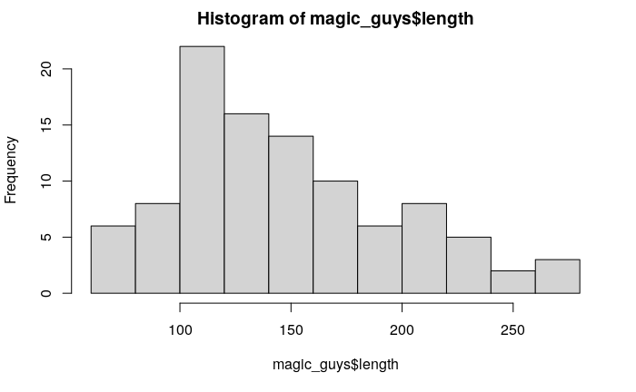

```r
# This plot will be plot all data as one distribution.
hist(magic_guys$length)
```

If all data in magic_guys$length is passed to the `hist()`, all data is plotted in the same distribution.

If we want to compare the distributions of the body heights of the two species, we need to separate data of 2 species before plot histogram to separate distribution of 2 samples. It can be observed that the group of “jedi” has a wider dispersion in taller population than the group of “sith”.

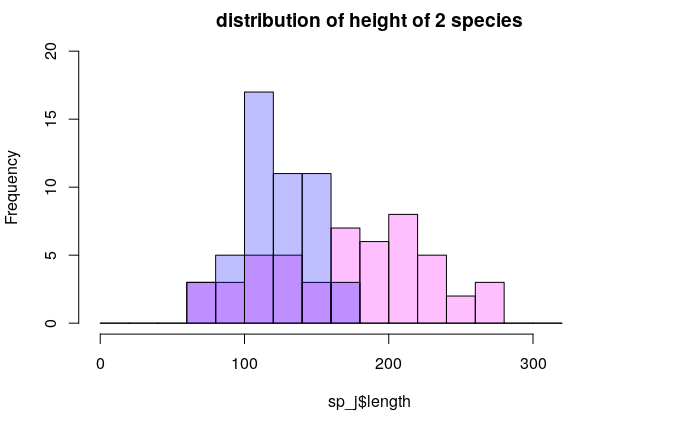

```r
# Separate data of 2 species
sp_j <- filter(magic_guys, species == "jedi")
sp_s <- filter(magic_guys, species == "sith")

# plot distribution
# last 2 letter of #ff00ff40 is for alpha of the color.
# set xlim and ylim to plot all distribution.
# set the same breaks to compare the same bin size.
breaks <- seq(0,max(magic_guys$length)+50, 20)
hist(sp_j$length, col = "#ff00ff40", xlim=c(0,max(magic_guys$length)+100), ylim=c(0,20), breaks = breaks,
     main="distribution of height of 2 species") # main to set title
hist(sp_s$length, col = "#0000ff40", xlim=c(0,max(magic_guys$length)+100), ylim=c(0,20), breaks = breaks, add = TRUE) # add = TRUE to overlap 2 plot
```

### a-3. Visualization of histograms - `ggplot2`

We can use `ggplot()` and `geom_histogram()` to plot the distribution as well.

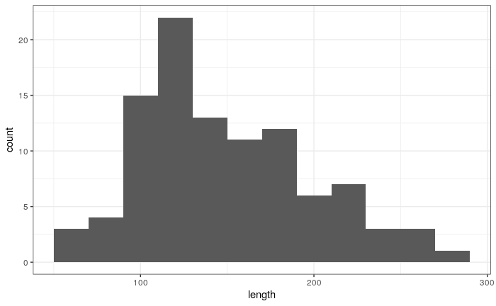

```r
# binwidth seems a close option of breaks in hist() function.
ggplot(magic_guys,aes(x=length)) +
  geom_histogram(binwidth = 20) +
  theme_bw() # white back ground theme
```

If we pass all data of length in magic_guys, the output plot shows only one distribution. To plot each distribution for the two species, we can use the options `fill` and `position`. The resulting plot is almost the same, but the default rule of the bin is different with `hist()` and `ggplot2`.

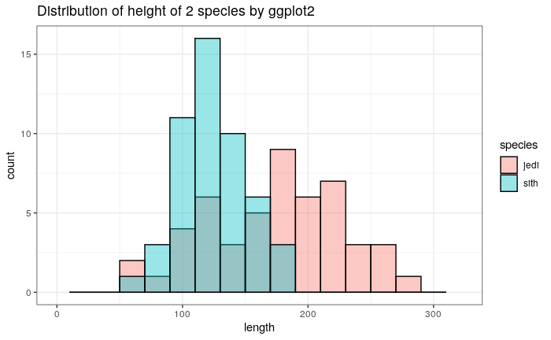

```r
# set fill to plot 2 species separately
ggplot(magic_guys,aes(x=length, fill = species )) +
  # set position as "identity" to overlay distribution
  # Also set color (black line of the bar) and alpha for visualization.
  geom_histogram(position = "identity", color = "black", alpha = 0.4, binwidth = 20) +
  xlim(0,max(magic_guys$length)+50) +
  theme_bw() + # white back ground theme
  ggtitle("Distribution of height of 2 species by ggplot2") # Title
```

### b. Visualization of boxplot - `ggplot2`

We can also compare the distribution of the two species using a boxplot. The black line in the box shows the median of the data, and the length of the box shows the interquartile range (IQR) which is 25% to 75% of the data. By looking at the boxplot, we may conclude that the group of “jedi” is taller than the group of “sith”.

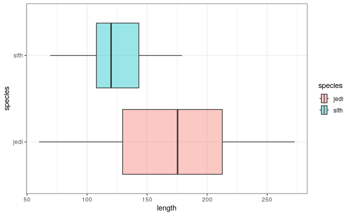

```r
# The argument of all x,y,fill in aes(x,y,fill) need to plot species separately.
ggplot(magic_guys,aes(x=length, y = species ,fill =species )) +
  geom_boxplot(alpha = 0.4) +
  theme_bw() # white back ground theme
```

If we want to see each data point, we can add `geom_jitter()` layer on top of the boxplot.

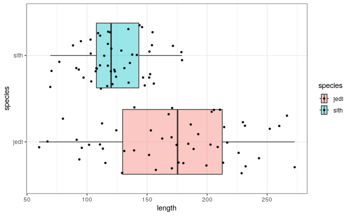

```r
ggplot(magic_guys,aes(x=length, y = species ,fill =species )) +
  geom_boxplot(alpha = 0.4) +
  geom_jitter(color="black", size=1, alpha=0.9) + # plot data point
  theme_bw() # white back ground theme
```

However, looking at each data point may not be enough to draw conclusions. Therefore, we can use a violin plot to visualize the distribution of the data as well. By looking at the violin plot, we can conclude that the group of “jedi” has a wider dispersion in taller population than the group of “sith”.

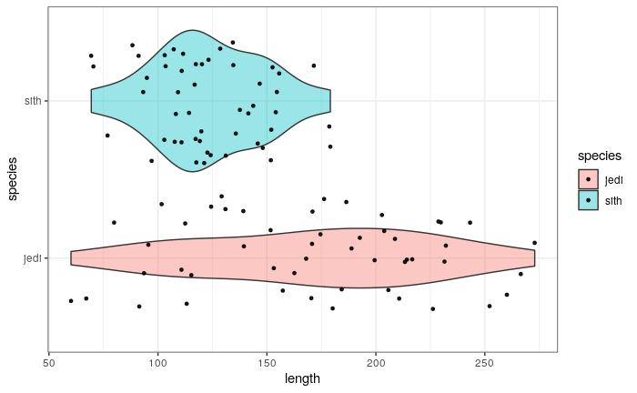

```r
ggplot(magic_guys,aes(x=length, y = species ,fill =species )) +
  # set position as "identity" to overlay distribution
  # Also set color (black line of the bar) and alpha for visualization.
  geom_violin(alpha = 0.4) +
  geom_jitter(color="black", size=1, alpha=0.9) +
  theme_bw() # white back ground theme
```

### c. Saving plots

To save plots in the `ggplot`, the function is `ggsave()`. The format of the output figure is defined by `device` option (“eps”, “ps”, “tex”, “pdf”, “jpeg”, “tiff”, “png”, “bmp”, “svg” or “wmf”).

PNG, PDF, and SVG are popular figure file formats with different best use cases. PNG is suitable for web graphics and can maintain image quality, but may result in a large file size and has a color mode that may affect print colors. PDF is ideal for print documents but is not easy to integrate into web pages. SVG is a vector format suitable for the web but not for high-quality digital photographs. In conclusion, for printing figures, PDF is the best option, and for web pages, SVG (not for digital photos) and PNG (although heavy) are suitable choices.

**Best figure format Summary**

- Print: PDF
- Web (plot): PNG, SVG

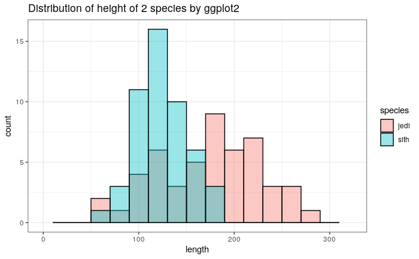

```r
ggplot(magic_guys,aes(x=length, fill = species )) +
  # set position as "identity" to overlay distribution
  # Also set color (black line of the bar) and alpha for visualization.
  geom_histogram(position = "identity", color = "black", alpha = 0.4, binwidth = 20) +
  xlim(0,max(magic_guys$length)+50) +
  theme_bw() + # white back ground theme
  ggtitle("Distribution of height of 2 species by ggplot2")
ggsave("magic_guys_hist_ggplot2.png", device="png")
ggsave("magic_guys_hist_ggplot2.pdf", device="pdf")
ggsave("magic_guys_hist_ggplot2.svg", device="svg")
```

If figure is not plotted by `ggplot2`, use `png()` or `pdf()` to save images.

```r
# This command causes an error when saving R notebook
## save as png
png("magic_guys_hist.png")

## plot block
breaks <- seq(0,max(magic_guys$length)+50, 20)
hist(sp_j$length, col = "#ff00ff40", xlim=c(0,max(magic_guys$length)+100), ylim=c(0,20), breaks = breaks, main="distribution of height of 2 species") # main to set title
hist(sp_s$length, col = "#0000ff40", xlim=c(0,max(magic_guys$length)+100), ylim=c(0,20), breaks = breaks, add = TRUE) # add = TRUE to overlap 2 plot

## close device
dev.off()
```

## 2. microarray_data.tab dataset

### a. How big is the matrix in terms of rows and columns?

Load `microarray_data.tab` using `read_tsv()`: This matrix contains 551 rows with 1000 columns (gene). The size of matrix is 551 x 1000. If data is filled in all places in the matrix, count of value will be 551,000.

```r
microarray_data <- read_tsv("../data/microarray_data.tab")
```

### b. Count the missing values per gene and visualize this result.

There are 115826 places with brank value (`NA`) thorough the matrix. Missing values per gene will counted using `colSums()` function.

```r
# count blank value (NA) thorough the matrix.
count_All_na = sum(is.na(microarray_data))
print(count_All_na)
```

```
[1] 115826
```

```r
# count blank value (NA) per gene
count_gens_na = colSums(is.na(microarray_data))
```

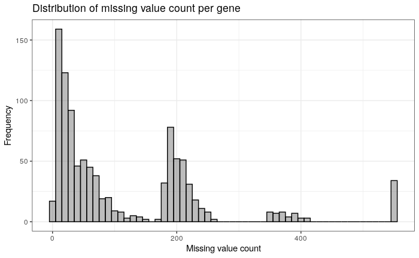

```r
# Convert named vector into data frame
count_gens_na_df <- data.frame(Value = count_gens_na, Name = names(count_gens_na))

# plot histogram
ggplot(count_gens_na_df,aes(x=Value)) +
  geom_histogram(color = "black", alpha = 0.4, binwidth = 10) +
  theme_bw() + # white back ground theme
  # Title and x, y labels
  labs(title = "Distribution of missing value count per gene", x = "Missing value count", y = "Frequency")
```

### c. Find the genes for which there are more than X% (X=10%, 20%, 50%) missing values.

Missing values of more than 10%, 20%, 50% will missing be more than 56 values (> 10%), 111 values (> 20%), 276 values (> 50%). The number of those genes will be 512 genes (missing >10%), 377 genes(missing >20%), and 74 genes(missing >50%).

```r
X <- c(0.1, 0.2, 0.5)

# Missing value number for each percentage
missing_value_seq <- X * dim(microarray_data)[1]
missing_value_seq
```

```
[1]  55.1 110.2 275.5
```

```r
# Genes with more than X% (X=10%, 20%, 50%) missing values.
more10 <- filter(count_gens_na_df, Value > missing_value_seq[1])
more20 <- filter(count_gens_na_df, Value > missing_value_seq[2])
more50 <- filter(count_gens_na_df, Value > missing_value_seq[3])

# count those genes
c(dim(more10)[1],  dim(more20)[1], dim(more50)[1])
```

```
[1] 512 377  74
```

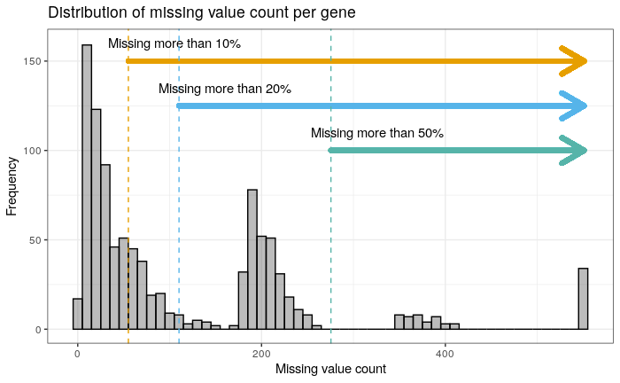

```r
# Convert named vector into data frame
count_gens_na_df <- data.frame(Value = count_gens_na, Name = names(count_gens_na))

# plot histogram
base <- ggplot(count_gens_na_df,aes(x=Value)) +
  geom_histogram(color = "black", alpha = 0.4, binwidth = 10) +
  theme_bw() + # white back ground theme
  # Title and x, y labels
  labs(title = "Distribution of missing value count per gene", x = "Missing value count", y = "Frequency")

# annotation of missing 10%
base <- base +
  geom_vline(xintercept = dim(microarray_data)[1]*0.1, color="#E69F00", linetype="dashed") + # 10%
  geom_segment(
    x = dim(microarray_data)[1]*0.1, y = 150,
    xend = dim(microarray_data)[1], yend = 150,
    lineend = "round", linejoin = "round",
    size = 2, arrow = arrow(length = unit(0.3, "inches")), colour = "#E69F00") +
  annotate("text", x = dim(microarray_data)[1]*0.1 + 50, y = 160, label = "Missing more than 10%")
# annotation of missing 20%
base <- base +
  geom_vline(xintercept = dim(microarray_data)[1]*0.2, color="#56B4E9",  linetype="dashed") +  # 20%
  geom_segment(
  x = dim(microarray_data)[1]*0.2, y = 125,
  xend = dim(microarray_data)[1], yend = 125,
  lineend = "round", linejoin = "round",
  size = 2, arrow = arrow(length = unit(0.3, "inches")), colour = "#56B4E9") +
  annotate("text", x = dim(microarray_data)[1]*0.2+ 50, y = 135, label = "Missing more than 20%")

# annotation of missing 50%
base <- base +
  geom_vline(xintercept = dim(microarray_data)[1]*0.5, color="#56B4A9",  linetype="dashed") + # 50%
  geom_segment(
  x = dim(microarray_data)[1]*0.5, y = 100,
  xend = dim(microarray_data)[1], yend = 100,
  lineend = "round", linejoin = "round",
  size = 2, arrow = arrow(length = unit(0.3, "inches")), colour = "#56B4A9")  +
  annotate("text", x = dim(microarray_data)[1]*0.5+ 50, y = 110, label = "Missing more than 50%")

print(base)
```

### d. Replace the missing value by the average expression value

To replacing missing value with mean of corresponding gene is as below.

- create function using `ifelse()` to find missing value to fill mean value of its column (gene)
- use `apply()` to apply created function though columns

```r
# A function to find missing value and fill mean value its column (gene)
# na.rm = TRUE to ignore weight of missing value when calculate mean.

find_na_fill_mean <- function(x){
  ifelse(is.na(x), mean(x, na.rm = TRUE), x)
}

microarray_data_filled <- apply(microarray_data, 2, find_na_fill_mean)
sum(colSums(is.na(microarray_data_filled)))/dim(microarray_data_filled)[1]
```

```
[1] 34
```

After filling missing value with mean, still 34 gene is missing because those genes are missing through 551 rows.

Next, I checked the distribution of mean value before and after filling missing value and distribution of difference to compare effect of filling in with mean value. Most of the gene does not change much after filling NA with mean value.

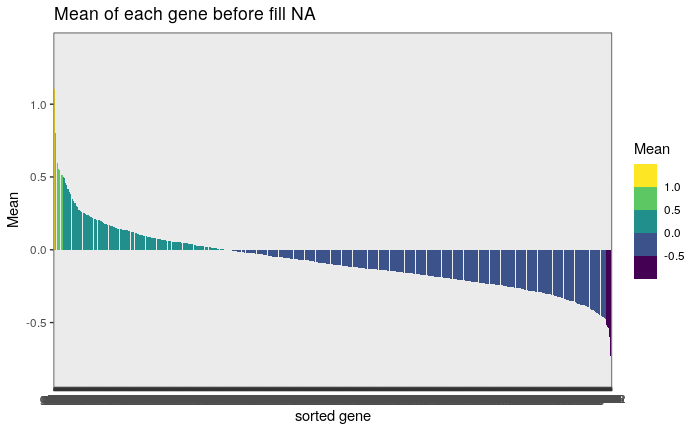

```r
microarray_data_mean <- colMeans(microarray_data, na.rm = TRUE)
microarray_data_mean_df <- data.frame(Mean = microarray_data_mean, Name = names(microarray_data_mean)) %>%
  drop_na(everything())

# plot histogram
base <- ggplot(microarray_data_mean_df,aes(x = fct_reorder(Name, -Mean, .fun = median), y = Mean,  fill =Mean)) +
  geom_bar(stat = "identity") +
  scale_fill_viridis_b() +
  theme_bw() + # white back ground theme
  labs(title = "Mean of each gene before fill NA", x="sorted gene")
print(base)
```

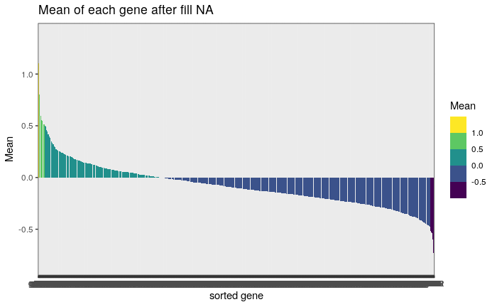

```r
microarray_data_mean_filled <- colMeans(microarray_data_filled, na.rm = TRUE)
microarray_data_mean_df_filled <- data.frame(Mean = microarray_data_mean_filled, Name = names(microarray_data_mean_filled)) %>%
  drop_na(everything())

# plot histogram
base <- ggplot(microarray_data_mean_df_filled,aes(x = fct_reorder(Name, -Mean, .fun = median), y = Mean,  fill =Mean)) +
  geom_bar(stat = "identity") +
  scale_fill_viridis_b() +
  theme_bw() + # white back ground theme
  labs(title = "Mean of each gene after fill NA", x="sorted gene")
print(base)
```

```r
diff_mean <- microarray_data_mean_df_filled$Mean - microarray_data_mean_df$Mean
diff_mean_df = data.frame(Diff = diff_mean, Name = microarray_data_mean_df_filled$Name)
max(diff_mean)
```

```
[1] 3.469447e-18
```

```r
min(diff_mean)
```

```
[1] -3.469447e-18
```

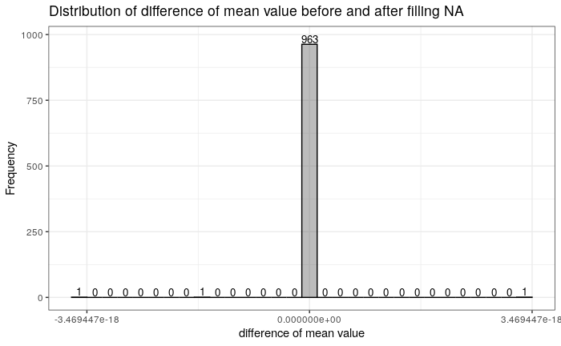

```r
base <- ggplot(diff_mean_df,aes(x=Diff)) +
  geom_histogram(color = "black", alpha = 0.4) +
  theme_bw() + # white back ground theme
  # Title and x, y labels
  labs(title = "Distribution of difference of mean value before and after filling NA", x = "difference of mean value", y = "Frequency") +
  stat_bin(geom="text", size=3.5, aes(label=..count.., y=20+(..count..))) +
  scale_x_continuous(breaks=c(min(diff_mean),0,max(diff_mean)))

print(base)
```

## 3. CO2 dataset

Contents of CO2 dataset as in Task5. > The CO2 dataset is from an experiment on the cold tolerance of the grass species *Echinochloa crus-galli* from Quebec and Mississippi. This data contains 84 observations (row) and 5 variables (column). There are 3 biological replicates for each 4 condition (Quebec-nonchilled, Quebec-chilled, Mississippi-nonchilled, Mississippi-chilled) and 7 different ambient carbon dioxide concentration for each sample (3 x 4 x 7 = 84). 5 variables include the unique identifier for each plant (*Plant*), the origin of the plant (*Type*), treatment (*Treatment*, which is `nonchilled` or `chilled`), the ambient carbon dioxide concentration (*conc*), the carbon dioxide uptake rates (*uptake*) of the plant.

To understand the data, I set 4 question as below.

1. Dose ambient carbon dioxide concentration relates carbon dioxide uptake rates?
2. Dose treatment relates carbon dioxide uptake rates?
3. Dose carbon dioxide uptake rates distribution is differ between the origin of the plant?
4. What is the overall conclusion of carbon dioxide uptake rates in 4 condition?

```r
data(CO2)
```

### 1. Dose ambient carbon dioxide concentration relates carbon dioxide uptake rates?

To answer this question, I plotted a scatter plot with ambient carbon dioxide concentration (`conc`) on the x-axis and carbon dioxide uptake rates (`uptake`) on the y-axis. The plot shows that higher ambient carbon dioxide concentrations result in higher carbon dioxide uptake rates. It also shows that carbon dioxide uptake rates saturate at ambient carbon dioxide concentration of 250 mL/L. This scatter plots did not show that there are individual differences in carbon dioxide uptake rates between plants. Therefore, I next visualized the changes in carbon dioxide uptake rates with ambient carbon dioxide concentration for the same individual data using line plot, colored by plant (`Plant`). This plot also shows that carbon dioxide uptake rates saturate at ambient carbon dioxide concentration of 250 mL/L. However maximum saturation amount are different between plant, and also treatment.

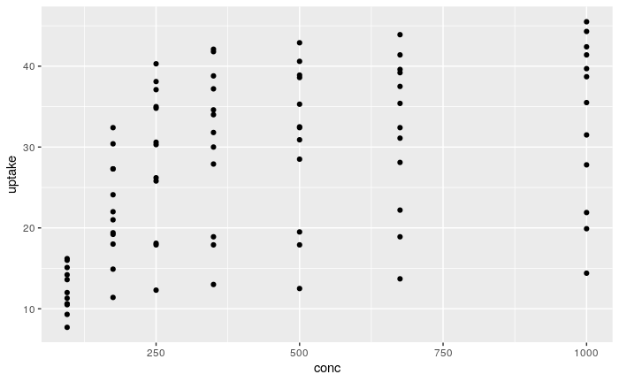

```r
p <- ggplot(CO2,aes(x=conc, y=uptake)) +
  geom_point()
print(p)
```

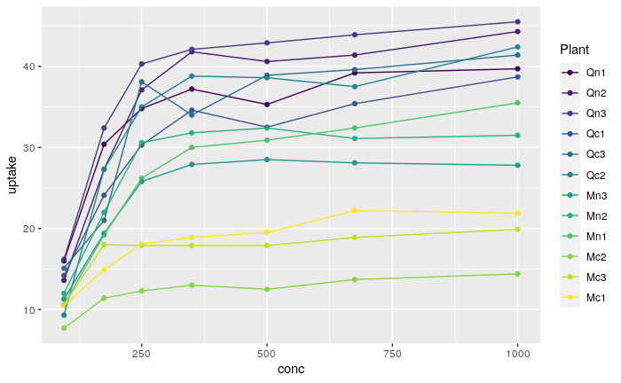

```r
p <- ggplot(CO2,aes(x=conc, y=uptake, color = Plant)) +
  geom_point() +
  geom_line()
print(p)
```

### 2. Dose treatment relates carbon dioxide uptake rates?

The line plot shows clear difference of relation between ambient carbon dioxide concentration and carbon dioxide uptake rates. To highlight the effect of the treatment, I change the color of the line and dot orange ( treatment = nonchilled), blue (treatment = chilled). The plots suggest that when treatment is chilled, there may be more variation due to the effect of origin. Therefore, the next plot was divided according to origin and colored according to treatment. The plot showed that treatment reduced carbon dioxide uptake rates, and suggested that the effect was stronger in Mississippi.

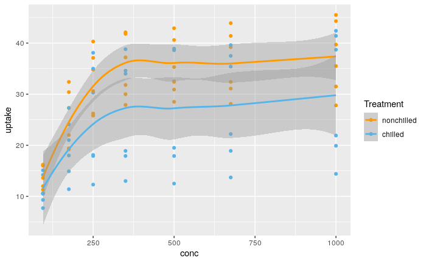

```r
p <- ggplot(CO2,aes(x=conc, y=uptake, color = Treatment)) +
  geom_point() +
  geom_smooth() +
  scale_color_manual(values = c("#ff9900", "#56B4E9"))
print(p)
```

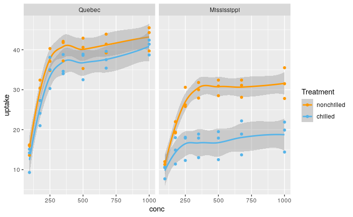

```r
p <- ggplot(CO2,aes(x=conc, y=uptake, color = Treatment)) +
  geom_smooth() +
  geom_point(aes(color = Treatment)) +
  facet_wrap(~Type, ncol=2) +
  scale_color_manual(values = c("#ff9900", "#56B4E9"))
print(p)
```

### 3. Dose carbon dioxide uptake rates distribution is differ between the origin of the plant?

The above plot visualized the differences in response by region of origin to the effect of the treatment, but it was difficult to see the differences in the original region of origin. Therefore, we drew a plot that was split by treatment and color by region of origin. The plot showed that carbon dioxide uptake rates were lower in Mississippi than in Quebec, irrespective of treatment.

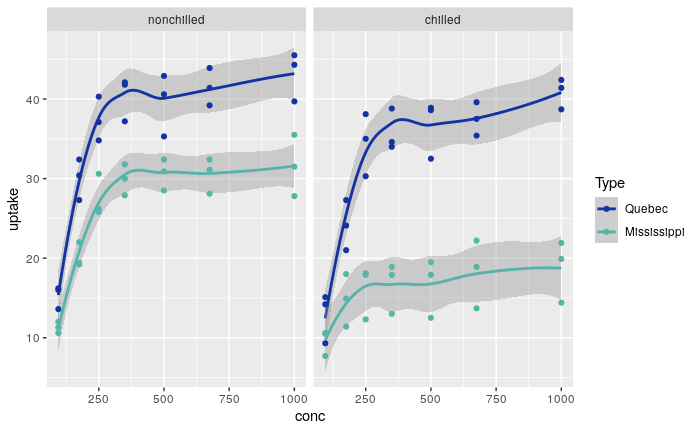

```r
p <- ggplot(CO2,aes(x=conc, y=uptake, color = Type)) +
  geom_smooth() +
  geom_point(aes(color = Type)) +
  facet_wrap(~Treatment, ncol=2) +
  scale_color_manual(values = c("#1333A3", "#56B4A9"))
print(p)
```

### 4. What is the overall conclusion of carbon dioxide uptake rates in 4 condition?

To conclude this data, the carbon dioxide uptake rate increases with the environmental carbon dioxide concentration and saturates when a certain concentration is reached, the amount of saturation depending on the region of origin and temperature.